## STAT 689 Homework 8

## Part 1

### You have the salinity data set, where there is a hint of possible heteroscedasticity. Let us pretend that the heteroscedasticity is real. Important: make sure you use the modified data set that tries to deal with the two large leverage points (Salinity_Data_Modified_Leverage_Points.csv). Also, use gam() with the default settings

```r
setwd("~/tamu/MS-STAT-2022/689-flexible-regression")
salinity = read.csv("Salinity_Data_Modified_Leverage_Points.csv")
```

### 1. Fit a GAM where salinity is regressed on a smooth function of discharge. Plot discharge (x-axis) against the absolute residuals from this fit (y-axis).

```r
library(mgcv)
```

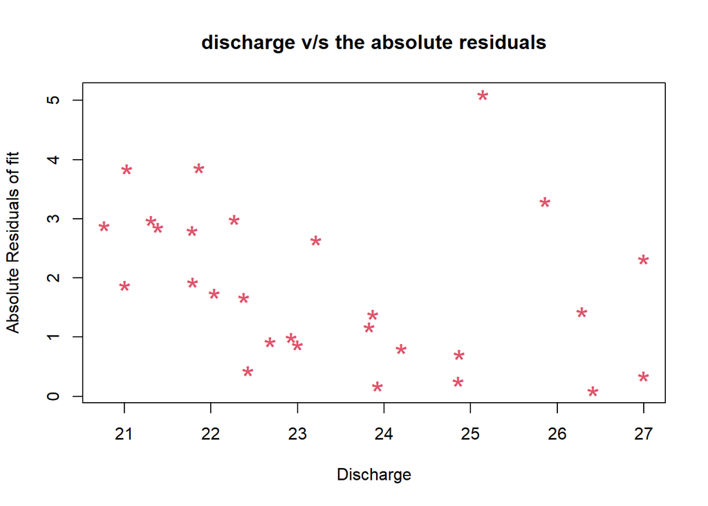

```r
salinity.gam.fit.default = gam(salinity ~ s(discharge) , data = salinity)
ord = order(salinity$discharge)
plot(salinity$discharge[ord] , abs(salinity.gam.fit.default$residuals), cex = 2 , pch = "*" , col = 2
     , xlab = "Discharge" , ylab = "Absolute Residuals of fit", main = "discharge v/s the absolute residuals")
```

### 2. Calculate the ratio of the maximum predicted absolute residual to the minimum predicted absolute residual

```r
abs.residuals = abs(salinity.gam.fit.default$residuals)
gam.abs.residuals.fit = gam(abs.residuals ~ s(salinity$discharge))
ratio = (max(abs(fitted(gam.abs.residuals.fit))) / min(abs(fitted(gam.abs.residuals.fit))))
ratio
```

```
## [1] 5.015066
```

### 3. Is there any concern from the calculation in (2) that heteroscedasticity might be an issue for pointwise confidence intervals?

The ratio is greater than the heuristic value of 3. So, we will have concern that heterscedasticity might be an issue for pointwise CIs.

### 4. Now do a weighted fit to the data, as described in Lecture 11. Plot discharge (x-axis) against the absolute residuals divided by estimated standard deviations (y-axis), as we did in class

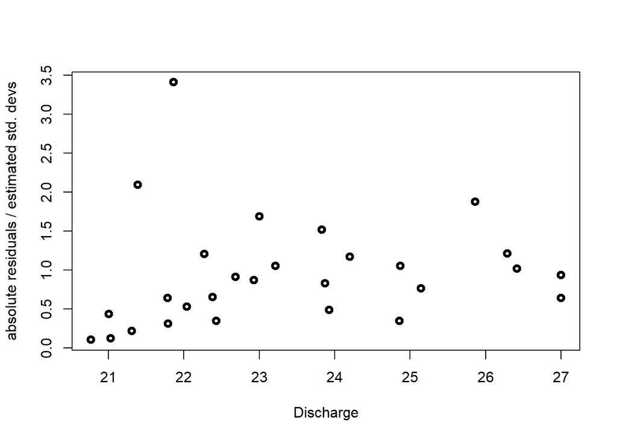

```r
weight = 1 / (fitted(gam.abs.residuals.fit) ^ 2)
salinity.gam.fit.default.weighted = gam(salinity ~ s(discharge) , data = salinity , weight = weight)
ord = order(salinity$discharge)
plot(salinity$discharge[ord],abs(salinity.gam.fit.default.weighted$residuals[ord])/fitted(gam.abs.residuals.fit)[ord],lwd=3
     , xlab = "Discharge" , ylab = "absolute residuals / estimated std. devs")
```

### 5. Compute the 95% confidence intervals for the unweighted and the weighted fits. Show them on a single plot without the data points

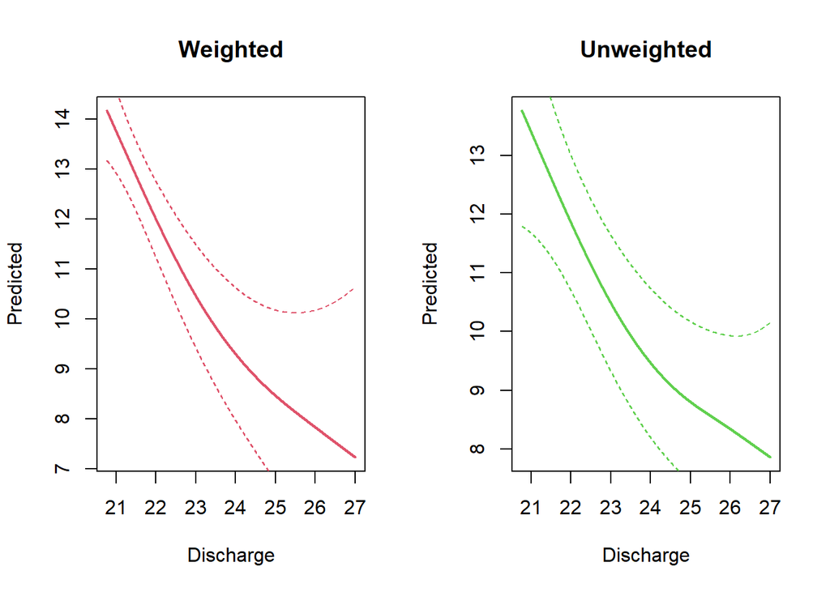

```r
par(mfrow = c(1 ,2))
discharge.data = seq(min(salinity$discharge) , max(salinity$discharge) , length = 10000)
predDischarge.weighted = predict(salinity.gam.fit.default.weighted , newdata = data.frame(discharge = discharge.data), se = TRUE)
predDischarge.unweighted = predict(salinity.gam.fit.default , newdata = data.frame(discharge = discharge.data), se = TRUE)

predDischarge.weighted.upper = predDischarge.weighted$fit + 1.96 * predDischarge.weighted$se.fit
predDischarge.weighted.lower = predDischarge.weighted$fit - 1.96 * predDischarge.weighted$se.fit

predDischarge.unweighted.upper = predDischarge.unweighted$fit + 1.96 *predDischarge.unweighted$se.fit
predDischarge.unweighted.lower = predDischarge.unweighted$fit - 1.96 *predDischarge.unweighted$se.fit

plot(discharge.data , predDischarge.weighted$fit , xlab = "Discharge" , ylab = "Predicted" , type = "l" , col = 2 , lwd = 2
     , main = "Weighted")

points(discharge.data , predDischarge.weighted.upper , lty = 2 , col = 2 , type = "l")
points(discharge.data , predDischarge.weighted.lower , lty = 2 , col = 2 , type = "l")

plot(discharge.data , predDischarge.unweighted$fit , xlab = "Discharge" , ylab = "Predicted" , type = "l" , col = 3 , lwd = 2, main = "Unweighted")

points(discharge.data , predDischarge.unweighted.upper , lty = 2 , col = 3 , type = "l")
points(discharge.data , predDischarge.unweighted.lower , lty = 2 , col = 3 , type = "l")
```

### 6. Are there any systematic differences in the two plots, as there were for the LIDAR Data? The code you need is in lidar_Weighted_Prediction.R, which you can easily modify

CI widths for weighted model are narrower than unweighted model, maybe towards the end the weighed seems to get wider.

## Part 2

### For this problem, please consult the file Heteroscedasticity_02-28-2023.pdf. That file is NOT part of the homework, but it gives a template

### Use the Framingham data with LSBP and Lcholest (Framingham_with_LSBP_and_Lcholest.csv).

```r
framingham = read.csv("Framingham_with_LSBP_and_Lcholest.csv")
```

### 7. Fit a factor-by-curve GAM where the binary response CHD is regressed on LSBP, Lcholest and Age modeled as splines, but allow the Age spline to interact with the factor Smoker. Plot the fitted splines to age for smokers and non-smokers. Use BostMortGAMfit_Interactions.R and BostMortFacByCurv.R as your models

```r
library(mgcv)
framingham.fit.factorbycurve.Int = gam(CHD ~ s(LSBP , bs = "cr")
                                   + s(Lcholest , bs = "cr")
                                   + s(Age , by = factor(Smoker) , bs = "cr")
                                   + factor(Smoker)
                                   , family = binomial(link = "logit"), data = framingham)
summary(framingham.fit.factorbycurve.Int)
```

```
##
## Family: binomial
## Link function: logit
##
## Formula:
## CHD ~ s(LSBP, bs = "cr") + s(Lcholest, bs = "cr") + s(Age, by = factor(Smoker),
##     bs = "cr") + factor(Smoker)
##
## Parametric coefficients:
##                 Estimate Std. Error z value Pr(>|z|)
## (Intercept)      -3.4426     0.3342 -10.301   <2e-16 ***
## factor(Smoker)1   0.7969     0.3492   2.282   0.0225 *
## ---
## Signif. codes:  0 '***' 0.001 '**' 0.01 '*' 0.05 '.' 0.1 ' ' 1
##
## Approximate significance of smooth terms:
##                          edf Ref.df Chi.sq  p-value
## s(LSBP)                1.626  2.045 16.400 0.000316 ***
## s(Lcholest)            1.001  1.003 19.954 8.57e-06 ***
## s(Age):factor(Smoker)0 1.001  1.001  7.959 0.004802 **
## s(Age):factor(Smoker)1 2.474  3.086 16.962 0.000789 ***
## ---
## Signif. codes:  0 '***' 0.001 '**' 0.01 '*' 0.05 '.' 0.1 ' ' 1
##
## R-sq.(adj) =  0.0468   Deviance explained = 9.95%
## UBRE = -0.49117  Scale est. = 1         n = 1615
```

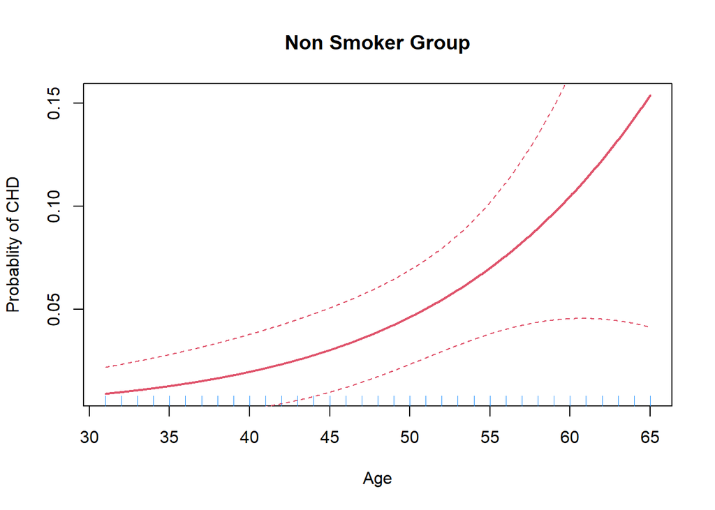

```r
ng = 1001

LSBPAveg = rep(mean(framingham$LSBP) , ng)
LCholestAveg = rep(mean(framingham$Lcholest) , ng)
Ageseq = seq(min(framingham$Age) , max(framingham$Age) , length = ng)

Nsmokerg = as.factor(rep(0 , ng))
smokerg = as.factor(rep(1 , ng))

fpredNsmoker = predict(framingham.fit.factorbycurve.Int ,type = "response",
                       newdata = data.frame(Lcholest = LCholestAveg , LSBP = LSBPAveg , Age = Ageseq , Smoker = Nsmokerg)
                       , se = TRUE)
fpredNsmokerUppper = fpredNsmoker$fit + 1.96 * fpredNsmoker$se.fit
fpredNsmokerLower = fpredNsmoker$fit - 1.96 * fpredNsmoker$se.fit

plot(Ageseq , fpredNsmoker$fit , col = 2 , xlab = "Age" , ylab = "Probablity of CHD" , main = "Non Smoker Group" ,  type = "l" , lwd = 2 ,
     xlim = c(min(Ageseq), max(Ageseq)))
lines(Ageseq ,fpredNsmokerUppper , col = 2 , lty = 2 )
lines(Ageseq ,fpredNsmokerLower , col = 2 , lty = 2 )
rug(framingham$Age , col = "dodgerblue",quiet = TRUE)
```

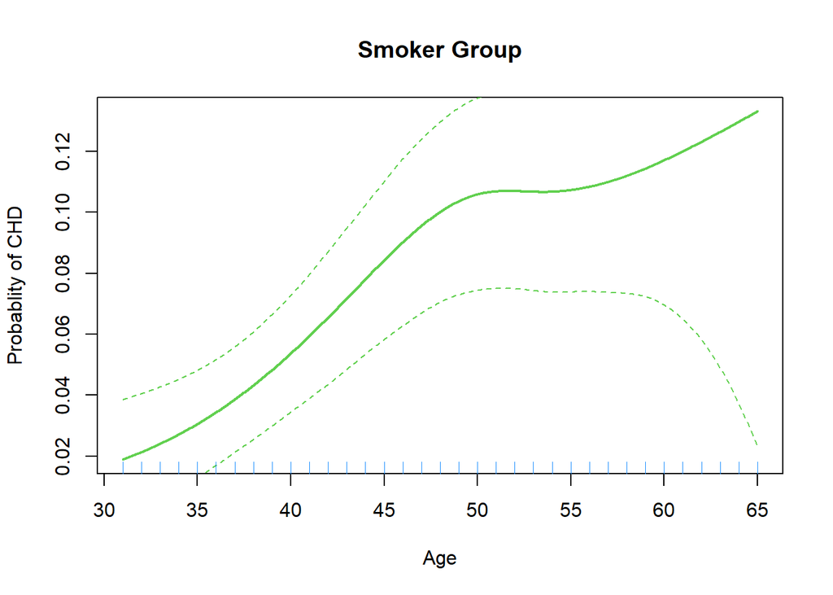

```r
fpredsmoker = predict(framingham.fit.factorbycurve.Int ,type = "response",
                       newdata = data.frame(Lcholest = LCholestAveg , LSBP = LSBPAveg , Age = Ageseq , Smoker = smokerg)
                       , se = TRUE)
fpredsmokerUppper = fpredsmoker$fit + 1.96 * fpredsmoker$se.fit
fpredsmokerLower = fpredsmoker$fit - 1.96 * fpredsmoker$se.fit

plot(Ageseq , fpredsmoker$fit , col = 3 , xlab = "Age" , ylab = "Probablity of CHD" , main = "Smoker Group" , type = "l" , lwd = 2 ,
     xlim = c(min(Ageseq), max(Ageseq)))
lines(Ageseq ,fpredsmokerUppper , col = 3 , lty = 2 )
lines(Ageseq ,fpredsmokerLower , col = 3 , lty = 2 )
rug(framingham$Age , col = "dodgerblue",quiet = TRUE)
```

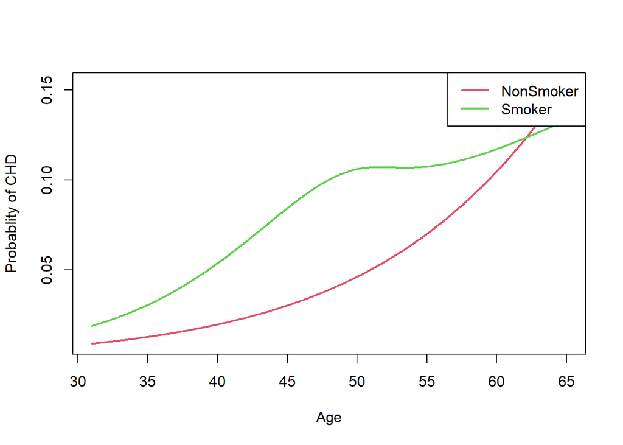

```r
plot(Ageseq , fpredNsmoker$fit , col = 2 , type = "l" , lwd = 2 , xlab = "Age" , ylab = "Probablity of CHD")
points(Ageseq , fpredsmoker$fit , col = 3 , type = "l" , lwd = 2)
legend("topright" , c("NonSmoker" , "Smoker") , lwd = 2 , col = 2:3)
```

### 8. In question (7), do you think there is any statistical evidence that the risk of developing coronary heart disease (CHD) over 8 years as a function of age depends on whether you are a smoker or not? Why or why not? Cite p-values and anything else you can fit into about 40 words

```r
framingham.fit.factorbycurve.NInt = gam(CHD ~ s(Lcholest , bs = "cr")
                                       + s(LSBP , bs = "cr")
                                       + s(Age , bs = "cr")
                                       + factor(Smoker)
                                       , family = binomial(link = "logit"), data = framingham)
anova(framingham.fit.factorbycurve.NInt, framingham.fit.factorbycurve.Int  , test = "Chisq")
```

```
## Analysis of Deviance Table
##
## Model 1: CHD ~ s(Lcholest, bs = "cr") + s(LSBP, bs = "cr") + s(Age, bs = "cr") +
##     factor(Smoker)
## Model 2: CHD ~ s(LSBP, bs = "cr") + s(Lcholest, bs = "cr") + s(Age, by = factor(Smoker),
##     bs = "cr") + factor(Smoker)
##   Resid. Df Resid. Dev    Df Deviance Pr(>Chi)
## 1    1607.2     807.76
## 2    1605.9     805.55 1.357   2.2111   0.2026
```